# Mastering Deep Neural Networks

[figure not shown]

# Learning Paradigms

- ### Machine Learning : automatically learn rules of a function to model a process in a dataset
- ### Deep Learning : use artificial neural networks to learn rules of a function to model a process in a dataset
- ### Artificial Intelligence : deep learning + knowledge bases + neuro-science + unknown

# Course Content

- ## Introduction to deep neural networks
- ## Practical perspective of applying deep learning
- ## Deep image processing using ConvNets
- ## Deep text processing using Word2Vec and LSTM

# Learn While You Code

Emphasis on problem solving and conceptual understanding

# Introduction To Artificial Neural Networks

## Goal of this class

- ### What is ANN? What is DNN?
- ### How is deep learning different from machine learning?
- ### How does a deep network work?
- ### Solve a problem using deep neural network

## Simplest form of ANN: Perceptron

- ### Invented in mid 20th century
- ### Loosely based on how brain functions
- ### Also called as a neuron, or a processing unit
- ### Basic building block of Deep Neural Networks (DNN)

[figure not shown]

## How does a neuron function

- ### Inputs
- ### Processing
- ### Output

How does a neuron function

[figure not shown]

## How does a perceptron function

- ### Inputs
- ### Processing
- ### Output

[figure not shown]

## How does a perceptron "learn" function

- ### Gradient descent algorithm is used to tune the weights.
- ### It is still unknown how the brain learns "strengths" of different neural connections.

## What if we connect/stack perceptrons?

- We get an aritifical neural network with multiple layers.
- Artificial Neural Network is an umbrella term to represent neural networks that have a set of perceptrons.
- The terms Deep Neural Networks and Artificial Neural Networks are used interchangeably.
- The use of the term deep neural networks signifies an aritifical neural network with a significant depth of layers.

### A fully connected deep network, also called as a multi-layer perceptron (MLP)

[figure not shown]

### Deep learning nuts-and-bolts

- ### Backpropagation algorithm
- ### Carefully choose different architectures for different problems
- ### Rapid experimentation to find the best function, i.e., neural network, for a give problem

# History

- 1980: Perceptron, MLP, CNN, RNN, backpropagation (but no big data, no GPUs)
- 1990: SVM, graphical models (evolved into ML/DM)
- 2009: Google Brain Project (big data: organize Google Images)
- 2012: Imagenet classification challenge (big compute: GPUs)
- 2013: Star faculties join big Internet-firms

# History

- 2014: DeepMind acquisition by Google (Deep Reinforcement Networks)
- 2015: CNN, RNN become mainstream (tex, audio, image, video)
- 2016: Google deploys NMT, AlphaGo
- 2018: Deep learning revolution continues

[figure not shown]

## Learning so far

- A perceptron
- A fully connected artificial neural network (ANN)
- Reasons why ANNs are a rage right now: ANNs are used to solve different problems in image, text, audio, video domain with different architectures, different types of connections, and different depths of neural layers.

# Compare deep learning with machine learning?

- ### Let's take a problem
- ### Apply traditional machine learning: logistic regression
- ### Apply a simple deep neural network

# Customer Churn Prediction

### Applications: telecom service providers, banks, employers

Business Problem: We have a dataset of a bank with 10,000 customers. The dataset contains lots of attributes of the customers measured over last 6 months such as name, credit score, grography, age, tenure, balance, numOfProducts, credit card, active member, estimated salary, exited, etc. We also know which of these customers stayed and left. Now, given a new customer profile, can we create a model out of this data that can predict whether the customer will leave or stay?

Generic problem: It is a classification problem with lots of independent variables. Based on these variables we're predicting a binary outcome.

This problem is valuable to any customer-oriented organisations, e.g. should this person get a loan or not? is this a fradulent transaction?

```python
%matplotlib inline
import matplotlib.pyplot as plt
import math
import seaborn as sns
import numpy as np
import pandas as pd
import warnings
warnings.filterwarnings('ignore')
```

```python
dataset = pd.read_csv('../data/Churn_Modelling.csv')
dataset.describe()
```

|  | RowNumber | CustomerId | CreditScore | Age | Tenure | Balance | NumOfProducts | HasCrCard | IsActiveMember | EstimatedSalary | Exited |
| --- | --- | --- | --- | --- | --- | --- | --- | --- | --- | --- | --- |
| count | 10000.00000 | 1.000000e+04 | 10000.000000 | 10000.000000 | 10000.000000 | 10000.000000 | 10000.000000 | 10000.00000 | 10000.000000 | 10000.000000 | 10000.000000 |
| mean | 5000.50000 | 1.569094e+07 | 650.528800 | 38.921800 | 5.012800 | 76485.889288 | 1.530200 | 0.70550 | 0.515100 | 100090.239881 | 0.203700 |
| std | 2886.89568 | 7.193619e+04 | 96.653299 | 10.487806 | 2.892174 | 62397.405202 | 0.581654 | 0.45584 | 0.499797 | 57510.492818 | 0.402769 |
| min | 1.00000 | 1.556570e+07 | 350.000000 | 18.000000 | 0.000000 | 0.000000 | 1.000000 | 0.00000 | 0.000000 | 11.580000 | 0.000000 |
| 25% | 2500.75000 | 1.562853e+07 | 584.000000 | 32.000000 | 3.000000 | 0.000000 | 1.000000 | 0.00000 | 0.000000 | 51002.110000 | 0.000000 |
| 50% | 5000.50000 | 1.569074e+07 | 652.000000 | 37.000000 | 5.000000 | 97198.540000 | 1.000000 | 1.00000 | 1.000000 | 100193.915000 | 0.000000 |
| 75% | 7500.25000 | 1.575323e+07 | 718.000000 | 44.000000 | 7.000000 | 127644.240000 | 2.000000 | 1.00000 | 1.000000 | 149388.247500 | 0.000000 |
| max | 10000.00000 | 1.581569e+07 | 850.000000 | 92.000000 | 10.000000 | 250898.090000 | 4.000000 | 1.00000 | 1.000000 | 199992.480000 | 1.000000 |

```python
# Quick look at the data
dataset.head()
```

|  | RowNumber | CustomerId | Surname | CreditScore | Geography | Gender | Age | Tenure | Balance | NumOfProducts | HasCrCard | IsActiveMember | EstimatedSalary | Exited |
| --- | --- | --- | --- | --- | --- | --- | --- | --- | --- | --- | --- | --- | --- | --- |
| 0 | 1 | 15634602 | Hargrave | 619 | France | Female | 42 | 2 | 0.00 | 1 | 1 | 1 | 101348.88 | 1 |
| 1 | 2 | 15647311 | Hill | 608 | Spain | Female | 41 | 1 | 83807.86 | 1 | 0 | 1 | 112542.58 | 0 |
| 2 | 3 | 15619304 | Onio | 502 | France | Female | 42 | 8 | 159660.80 | 3 | 1 | 0 | 113931.57 | 1 |
| 3 | 4 | 15701354 | Boni | 699 | France | Female | 39 | 1 | 0.00 | 2 | 0 | 0 | 93826.63 | 0 |
| 4 | 5 | 15737888 | Mitchell | 850 | Spain | Female | 43 | 2 | 125510.82 | 1 | 1 | 1 | 79084.10 | 0 |

```python
# Describing all the Categorical Features
dataset.describe(include=['O'])
```

|  | Surname | Geography | Gender |
| --- | --- | --- | --- |
| count | 10000 | 10000 | 10000 |
| unique | 2932 | 3 | 2 |
| top | Smith | France | Male |
| freq | 32 | 5014 | 5457 |

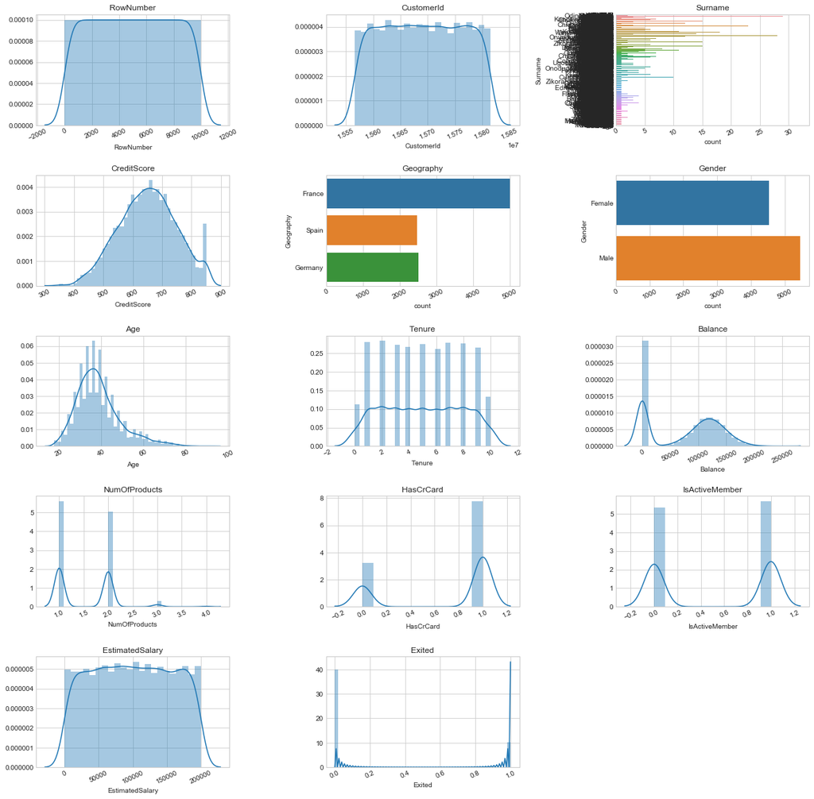

```python
# Plot of the distribution of each feature
def plot_distribution(dataset, cols=5, width=20, height=15, hspace=0.2, wspace=0.5):
    plt.style.use('seaborn-whitegrid')
    fig = plt.figure(figsize=(width,height))
    fig.subplots_adjust(left=None, bottom=None, right=None, top=None, wspace=wspace, hspace=hspace)
    rows = math.ceil(float(dataset.shape[1]) / cols)
    for i, column in enumerate(dataset.columns):
        ax = fig.add_subplot(rows, cols, i + 1)
        ax.set_title(column)
        if dataset.dtypes[column] == np.object:
            g = sns.countplot(y=column, data=dataset)
            substrings = [s.get_text()[:18] for s in g.get_yticklabels()]
            g.set(yticklabels=substrings)
            plt.xticks(rotation=25)
        else:
            g = sns.distplot(dataset[column])
            plt.xticks(rotation=25)

plot_distribution(dataset, cols=3, width=20, height=20, hspace=0.45, wspace=0.5)
```

```python
X = dataset.iloc[:, 3:13].values
y = dataset.iloc[:, 13].values
```

## Data preprocessing

### Encode categorical variables appropriately (e.g., a country/gender name to a value)

```python
# Encoding categorical data
# Encode before splitting because matrix X and independent variable Y must be already encoded
# Found two categorical data (country, gender)
# create dummy variables, avoid dummy variable trap
from sklearn.preprocessing import LabelEncoder, OneHotEncoder
labelencoder_X_1 = LabelEncoder()
X[:, 1] = labelencoder_X_1.fit_transform(X[:, 1])
labelencoder_X_2 = LabelEncoder()
X[:, 2] = labelencoder_X_2.fit_transform(X[:, 2])
onehotencoder = OneHotEncoder(categorical_features = [1])
X = onehotencoder.fit_transform(X).toarray()
X = X[:, 1:]
```

## Data normalization

### Scale features to be in a single range

```python
# Splitting the dataset into the Training set and Test set
from sklearn.model_selection import train_test_split
X_train, X_test, y_train, y_test = train_test_split(X, y, test_size = 0.2, random_state = 0)

# Feature Scaling
# lots of high computation to ease calculation, we don't want any particular independent variable dominating
from sklearn.preprocessing import StandardScaler
sc = StandardScaler()
X_train = sc.fit_transform(X_train)
X_test = sc.transform(X_test)
```

```python
# Function that runs the requested algorithm and returns the accuracy metrics
def fit_algo(algo, X_train, y_train, X_test, cv):
    model = algo.fit(X_train, y_train)
    test_pred = model.predict(X_test)
    probs = model.predict_proba(X_test)[:,1]

    acc = round(model.score(X_test, y_test) * 100, 2)
    # CV
    train_pred = model_selection.cross_val_predict(algo,
                                                  X_train,
                                                  y_train,
                                                  cv=cv,
                                                  n_jobs = -1)
    acc_cv = round(metrics.accuracy_score(y_train, train_pred) * 100, 2)
    return train_pred, test_pred, acc, acc_cv, probs
```

```python
# calculate the fpr and tpr for all thresholds of the classification
def plot_roc_curve(y_test, preds):
    fpr, tpr, threshold = metrics.roc_curve(y_test, preds)
    roc_auc = metrics.auc(fpr, tpr)
    plt.title('Receiver Operating Characteristic')
    plt.plot(fpr, tpr, 'b', label = 'AUC = %0.2f' % roc_auc)
    plt.legend(loc = 'lower right')
    plt.plot([0, 1], [0, 1],'r--')
    plt.xlim([-0.01, 1.01])
    plt.ylim([-0.01, 1.01])
    plt.ylabel('True Positive Rate')
    plt.xlabel('False Positive Rate')
    plt.show()
```

## Let's solve the problem using an ML technique

```python
import time
import datetime
from sklearn.linear_model import LogisticRegression
from sklearn import model_selection
from sklearn import metrics

# Logistic Regression
start_time = time.time()
train_pred_log, test_pred_log, acc_log, acc_cv_log, probs_log = fit_algo(LogisticRegression(),
                                                                 X_train,
                                                                 y_train,
                                                                 X_test,
                                                                 10)
log_time = (time.time() - start_time)
print("Accuracy: %s" % acc_log)
print("Accuracy CV 10-Fold: %s" % acc_cv_log)
print("Running Time: %s" % datetime.timedelta(seconds=log_time))
```

```
Accuracy: 81.1
Accuracy CV 10-Fold: 80.84
Running Time: 0:00:01.461247
```

Input data points are mapped to region near 0 or 1.

[figure not shown]

Properties of a logistic function:

- Differentiable : we can apply gradient descent based optimizations
- First derivative is non-negative : helps to compute the direction of weight adjustments
- Output between 0 to 1 : helps to predict an outcome with a probability
- *Logistic was one of the earliest functions to be used as processing unit of a perceptron.*

[figure not shown]

## Recap

- ### Binary classification problem
- ### Data preprocessing
- ### Data normalization
- ### Application of logistic regression

## Let's revisit some math

- ### Logistic regression and binary cross-entropy
- ### Derivative of loss/cost function
- ### Gradient descent algorithm

Logistic regression: prediction function vs loss function

[figure not shown]

Gradient descent for logistic regression

[figure not shown]

Gradient descent is an optimization algorithm. Optimization algorithm determines changes in the weights or parameters of a model. However, note that, the changes in hyper-parameter such as learning rate etc are determined by an optimization method, i.e., an optimization algorithm is different from an optimization method.

[figure not shown]

## Traditional machine learning

- ### choice of algorithm
- ### feature engineering
- ### structured data

The process of solving a problem using machine learning

[figure not shown]

Basic building blocks of machine/deep learning programming

[figure not shown]

Instances for each building block

[figure not shown]

## Deep learning

- ### choice of architecture (for today's class: Multi-Layer Perceptron: MLP)
- ### automatic feature engineering
- ### structured as well as unstructured data

We have already got introduced to multi-layer perceptron.

[figure not shown]

Two factors that have made deep neural networks popular in recent time.

[figure not shown]

## Recap

- ### Artificial/Deep Neural Networks: layered set of processing units connected in a specific manner
- ### Automatic feature engineering: similar architecture can be used to learn different functions

## Software platforms for deep learning

### Tensorflow, PyTorch, MXNET, Caffe, Keras

Keras is a wrapper library on top of Tensorflow which is a comprehensive deep neural network development framework. Tensorflow compiles a network defined in Keras into a static graph that gets executed and learned over time.

[figure not shown]

```python
import matplotlib.pyplot as plt
import keras
from sklearn.preprocessing import StandardScaler
from sklearn.preprocessing import LabelEncoder
from keras.utils import np_utils
from sklearn.model_selection import train_test_split
from keras.callbacks import EarlyStopping, ModelCheckpoint
from keras.models import Sequential
from keras.layers import Dense, Activation
```

```python
# Part 2 - Making the ANN/MLP

# Importing the Keras libraries and package
# Sequential module - initialize neural network
# Dense - layers of ANN
import keras
from keras.models import Sequential
from keras.layers import Dense
from keras.layers import Dropout
# Initialising the ANN
classifier = Sequential()

# Adding the input layer and the first hidden layer with dropout
# Take average of input + output for units/output_dim param in Dense
# input_dim is necessary for the first layer as it was just initialized
classifier.add(Dense(6, input_dim = 11, kernel_initializer = 'glorot_uniform', activation = 'relu' ))

# Adding the second hidden layer with dropout
# doesn't need the input_dim params
# kernel_initializer updates weights
# activation function - rectifier
classifier.add(Dense(6, kernel_initializer = 'glorot_uniform', activation = 'relu' ))

# Adding the output layer
# dependent variable with more than two categories (3), output_dim needs to change (e.g. 3), activation function - sufmax
classifier.add(Dense(1, kernel_initializer = 'glorot_uniform', activation = 'sigmoid' ))

# Compiling the ANN - applying Stochastic Gradient Descent to whole ANN
# Several different SGD algorithms
# mathematical details based on the loss function
# binary_crossentropy, categorical_cross_entropy
classifier.compile(optimizer = 'adam', loss = 'binary_crossentropy', metrics = ['accuracy'])

# Fitting the ANN to the Training Set
# X_train, y_train, Batch size, Epochs (whole training set)
history=classifier.fit(X_train, y_train, batch_size = 16, epochs = 25, validation_data=(X_test, y_test))
```

```
Train on 8000 samples, validate on 2000 samples
```

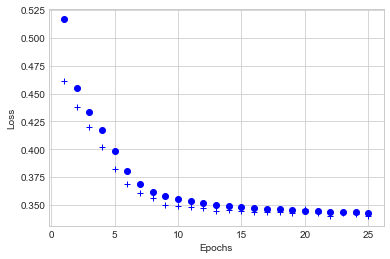

```python
import matplotlib.pyplot as plt
%matplotlib inline

history_dict = history.history
loss_values = history_dict['loss']
val_loss_values = history_dict['val_loss']
epochs = range(1, len(loss_values) + 1)

plt.plot(epochs, loss_values, 'bo')
plt.plot(epochs, val_loss_values, 'b+')
plt.xlabel('Epochs')
plt.ylabel('Loss')

plt.show()
```

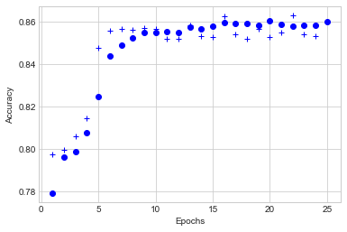

```python
plt.clf()

acc_values = history_dict['acc']
val_acc_values = history_dict['val_acc']

plt.plot(epochs, acc_values, 'bo')
plt.plot(epochs, val_acc_values, 'b+')
plt.xlabel('Epochs')
plt.ylabel('Accuracy')

plt.show()
```

```python
# Part 3 - Making the predictions and evaluating the model

# Predicting the Test set results
# Training set, see if the new data probability is right
y_pred = classifier.predict(X_test)
y_pred = (y_pred > 0.5)
print(y_pred)
```

```
[[False]
 [False]
 [False]
 ...
 [False]
 [False]
 [False]]
```

```python
# Part 3 - Making the predictions and evaluating the model

# Predicting a single new observation
new_prediction = classifier.predict(sc.transform(np.array([[0, 0, 600, 1, 40, 3, 60000, 2, 1, 1, 50000]])))
new_prediction = (new_prediction > 0.5)
# Making the Confusion Matrix
from sklearn.metrics import confusion_matrix
cm = confusion_matrix(y_test, y_pred)
print("\n\n confusion matrix \n\n", cm)
acc_cv = round(metrics.accuracy_score(y_test, y_pred) * 100, 2)
print("\n\n accuracy:", acc_cv)
```

```
 confusion matrix

 [[1524   71]
 [ 209  196]]


 accuracy: 86.0
```

[figure not shown]

## Recap

- ### Fully connected neural network : multi-layer perceptron (MLP)
- ### MLP learns a binary classification model
- ### Better accuracy than logistic regression

Revisiting the basic building blocks of deep/machine learning

[figure not shown]

Instances of each building block in case of current deep network

[figure not shown]

Optimization algorithm vs optimization method

[figure not shown]

# Traditional Machine Learning

- ### Algorithms: Logistic regression, SVM, decision trees
- ### Characteristics
  - ### choice of algorithm
  - ### feature engineering
  - ### structured data (generated by systems of records)

Machine learning is about learning a problem specific function with a set of weights/parameters.

[figure not shown]

Machine learning needs feature engineering and careful selection of algorithms. The algorithms are shallow networks such as SVM or logistic regression.

[figure not shown]

### Applications

- Gmail: is this email a spam?
- LinkedIn: is job J a job recommendation for user U?
- Flipkart: is this a fraudulent transaction?
- Bing: what is the relevance of Page P to query Q?

# Deep Learning

- ### Architectures: ConvNets, LSTM
- ### Characteristics:
  - ### choice of architecture
  - ### automatic feature engineering
  - ### structured as well as unstructured data (text, images)
  - ### increase depth to learn complex functions

Deep learning is also about learning a function defined by an architecture and a set of weights/parameters. However, we don't need explicit feature engineering, and deep learning can perform better with increase in data and increase in depth of the network.

[figure not shown]

### Applications

- Google: is this image a spam?
- Skype: translate english to hindi
- Flipkart: show similar fashion products
- Uber: should the car accelerate or stop?

## A Single Layer Network is A Universal Approximator

If f(x) is a non-linear function, then in theory, a neural network even with 1 hidden layer can perfectly learn to solve any classification problem. That is, a neural network with a set of weights exists that can produce the classification targets from the input data.

Why do we then consider deep neural networks?

## Shallow Network vs Deep Network

- Long breadth vs tall depth (Shallow vs Deep neural networks)
- Deep networks converge faster
- Deep networks needs substantially lesser number of weights than shallow networks
- Deep networks can learns hierarchical representation
- Challenge: finding the right deep network architecture for a given problem
- That is why we have variations such as CNN, LSTM with varying depths, varying activation functions, and different types of connections

[figure not shown]

# Applications of deep learning

- Image classification, object extraction from images and videos
- Speech recognition and translation
- Sentiment identification from text paragraphs

[figure not shown]

# Take Aways

- Perceptron
- Multi-layer perceptron
- Machine learning vs deep learning
- Basic building blocks of ML/DL
- Deep learning applications

# Optional

```python
from tensorflow.python.client import device_lib
print(device_lib.list_local_devices())
```

```
[name: "/device:CPU:0"
device_type: "CPU"
memory_limit: 268435456
locality {
}
incarnation: 788997178639137125
]
```

```python
# Part 4 - Evaluating, Improving and Tuning the ANN

# Evaluating the ANN
# Keras wrapper and Sci-kit Learn for k-Fold Cross Validation
from keras.wrappers.scikit_learn import KerasClassifier
from sklearn.model_selection import cross_val_score
from keras.models import Sequential
from keras.layers import Dense
def build_classifier():
    classifier = Sequential()
    classifier.add(Dense(6, input_dim = 11, kernel_initializer = 'glorot_uniform', activation = 'relu' ))
    classifier.add(Dense(6, kernel_initializer = 'glorot_uniform', activation = 'relu' ))
    classifier.add(Dense(1, kernel_initializer = 'glorot_uniform', activation = 'sigmoid' ))
    classifier.compile(optimizer = 'adam', loss = 'binary_crossentropy', metrics = ['accuracy'])
    return classifier
# k-Fold cross validator to check if the real relevant accuracy or the second one
#ß and where we are in bias-variance tradeoffs
classifier = KerasClassifier(build_fn = build_classifier, batch_size = 16, nb_epoch = 25)
accuracies = cross_val_score(estimator = classifier, X = X_train, y = y_train, cv = 10)
mean = accuracies.mean()
variable = accuracies.std()
```

```python
# overfitting is when the model has very high accuracy on training set but low accuracy on test set.
# this implies that the model does not generalize well, and does not perform well in practice.
# drop out is a regularization technique that sets random neurons to zero.
# this loosely models forgetting function in our brain
# this ensures that, over time, only strong neurons get fired and contribute to the model predictions
# weak neurons get turned off, and does not contribute to memorization/overfitting.

from keras.wrappers.scikit_learn import KerasClassifier
from sklearn.model_selection import GridSearchCV
from keras.models import Sequential
from keras.layers import Dense
def build_classifier(optimzer):
    classifier = Sequential()
    classifier.add(Dense(6, input_dim = 11, kernel_initializer = 'glorot_uniform', activation = 'relu' ))
    classifier.add(Dropout(p = 0.2))
    classifier.add(Dense(6, kernel_initializer = 'glorot_uniform', activation = 'relu' ))
    classifier.add(Dropout(p = 0.2))
    classifier.add(Dense(1, kernel_initializer = 'glorot_uniform', activation = 'sigmoid' ))
    classifier.add(Dropout(p = 0.2))
    classifier.compile(optimizer = optimzer, loss = 'binary_crossentropy', metrics = ['accuracy'])
    return classifier
classifier = KerasClassifier(build_fn = build_classifier)
parameters = {'batch_size': [25, 32],
              'nb_epoch': [100, 500],
              'optimzer': ['adam', 'rmsprop']}
grid_search = GridSearchCV(estimator = classifier,
                           param_grid = parameters,
                           scoring = 'accuracy',
                           cv = 10)
grid_search = grid_search.fit(X_train, y_train)
best_parameters = grid_search.best_params_
best_accuracy = grid_search.best_score_
```

```python
best_accuracy
```

```
0.79625
```